# Exploratory Data Analysis

```python
import os
import time
import torch
from torch.utils.data import DataLoader, Dataset
from torchvision.utils import make_grid
from torchvision import transforms
from collections import defaultdict
from torchvision.datasets.folder import pil_loader
import random
import numpy as np
import pandas as pd
import matplotlib.pyplot as plt
import pylab
from skimage import io, transform

pd.set_option('max_colwidth', 800)

%matplotlib inline
```

## Load Data

We have seven categories of musculoskeletal radiographs

```python
train_df = pd.read_csv('d:/image datasets/MURA-v1.1/train_image_paths.csv', names=['path'])
train_label_df = pd.read_csv('d:/image datasets/MURA-v1.1/train_labeled_studies.csv', names=['path','label'])
valid_df = pd.read_csv('d:/image datasets/MURA-v1.1/valid_image_paths.csv', names=['path'])
valid_label_df = pd.read_csv('d:/image datasets/MURA-v1.1/valid_labeled_studies.csv', names=['path','label'])

valid_df['label']=train_label_df['label']
train_df['label']=train_label_df['label']
valid_df

import csv

export_csv = train_df.to_csv (r'D:\image datasets\MURA-v1.1\train_data.csv', index = None, header=True) #Don't forget to add '.csv' at the end of the path
```

Let's checkout the shapes of dataframes

```python
train_df.shape, valid_df.shape
```

```
((36808, 2), (3197, 2))
```

```python
train_df.head(3)
```

|  | path | label |
| --- | --- | --- |
| 0 | MURA-v1.1/train/XR_SHOULDER/patient00001/study1_positive/image1.png | 1.0 |
| 1 | MURA-v1.1/train/XR_SHOULDER/patient00001/study1_positive/image2.png | 1.0 |
| 2 | MURA-v1.1/train/XR_SHOULDER/patient00001/study1_positive/image3.png | 1.0 |

```python
valid_df.head(3)
```

|  | path | label |
| --- | --- | --- |
| 0 | MURA-v1.1/valid/XR_WRIST/patient11185/study1_positive/image1.png | 1 |
| 1 | MURA-v1.1/valid/XR_WRIST/patient11185/study1_positive/image2.png | 1 |
| 2 | MURA-v1.1/valid/XR_WRIST/patient11185/study1_positive/image3.png | 1 |

So, we have radiograph paths and their correspoinding labels, each radiographs has a label of 0 (normal) or 1 (abnormal)

## Analysis

According to paper:  
1.

```
The MURA abnormality detection task is a binary classification task, where the input is an upper
exremity radiograph study — with each study containing one or more views (images) — and the
expected output is a binary label y ∈ {0, 1} indicating whether the "study" is normal or abnormal,
respectively.
```

2.

```
The model takes as input one or more views for a study of an upper extremity. On each view, our 169-
layer convolutional neural network predicts the probability of abnormality. We compute the overall
probability of abnormality for the study by taking the arithmetic mean of the abnormality
probabilities output by the network for each image. The model makes the binary prediction of
abnormal if the probability of abnormality for the study is greater than 0.5.
```

So, we have make predictions on study level, taking into account the predictions of all the views (images) of the study. This can be done by taking arithmetic mean of all the views (images) under a particular study.

```python
train_df.head(30)
```

|  | path | label |
| --- | --- | --- |
| 0 | MURA-v1.1/train/XR_SHOULDER/patient00001/study1_positive/image1.png | 1.0 |
| 1 | MURA-v1.1/train/XR_SHOULDER/patient00001/study1_positive/image2.png | 1.0 |
| 2 | MURA-v1.1/train/XR_SHOULDER/patient00001/study1_positive/image3.png | 1.0 |
| 3 | MURA-v1.1/train/XR_SHOULDER/patient00002/study1_positive/image1.png | 1.0 |
| 4 | MURA-v1.1/train/XR_SHOULDER/patient00002/study1_positive/image2.png | 1.0 |
| 5 | MURA-v1.1/train/XR_SHOULDER/patient00002/study1_positive/image3.png | 1.0 |
| 6 | MURA-v1.1/train/XR_SHOULDER/patient00003/study1_positive/image1.png | 1.0 |
| 7 | MURA-v1.1/train/XR_SHOULDER/patient00003/study1_positive/image2.png | 0.0 |
| 8 | MURA-v1.1/train/XR_SHOULDER/patient00003/study1_positive/image3.png | 1.0 |
| 9 | MURA-v1.1/train/XR_SHOULDER/patient00004/study1_positive/image1.png | 1.0 |
| 10 | MURA-v1.1/train/XR_SHOULDER/patient00004/study1_positive/image2.png | 1.0 |
| 11 | MURA-v1.1/train/XR_SHOULDER/patient00004/study1_positive/image3.png | 1.0 |
| 12 | MURA-v1.1/train/XR_SHOULDER/patient00004/study1_positive/image4.png | 1.0 |
| 13 | MURA-v1.1/train/XR_SHOULDER/patient00005/study1_positive/image1.png | 1.0 |
| 14 | MURA-v1.1/train/XR_SHOULDER/patient00006/study1_positive/image1.png | 1.0 |
| 15 | MURA-v1.1/train/XR_SHOULDER/patient00006/study1_positive/image2.png | 1.0 |
| 16 | MURA-v1.1/train/XR_SHOULDER/patient00007/study1_positive/image1.png | 1.0 |
| 17 | MURA-v1.1/train/XR_SHOULDER/patient00007/study1_positive/image2.png | 1.0 |
| 18 | MURA-v1.1/train/XR_SHOULDER/patient00007/study1_positive/image3.png | 1.0 |
| 19 | MURA-v1.1/train/XR_SHOULDER/patient00007/study2_negative/image1.png | 1.0 |
| 20 | MURA-v1.1/train/XR_SHOULDER/patient00007/study2_negative/image2.png | 1.0 |
| 21 | MURA-v1.1/train/XR_SHOULDER/patient00007/study2_negative/image3.png | 1.0 |
| 22 | MURA-v1.1/train/XR_SHOULDER/patient00007/study2_negative/image4.png | 1.0 |
| 23 | MURA-v1.1/train/XR_SHOULDER/patient00008/study1_positive/image1.png | 1.0 |
| 24 | MURA-v1.1/train/XR_SHOULDER/patient00008/study1_positive/image2.png | 1.0 |
| 25 | MURA-v1.1/train/XR_SHOULDER/patient00008/study1_positive/image3.png | 1.0 |
| 26 | MURA-v1.1/train/XR_SHOULDER/patient00009/study1_positive/image1.png | 1.0 |
| 27 | MURA-v1.1/train/XR_SHOULDER/patient00010/study1_positive/image1.png | 1.0 |
| 28 | MURA-v1.1/train/XR_SHOULDER/patient00010/study1_positive/image2.png | 1.0 |
| 29 | MURA-v1.1/train/XR_SHOULDER/patient00011/study1_positive/image1.png | 1.0 |

### Plot some random radiographs from training and validation set

```python
train_mat = train_df.as_matrix()
valid_mat = valid_df.as_matrix()
```

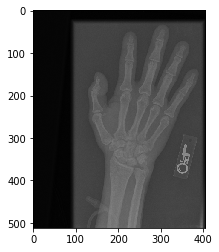

```python
os.chdir('d:/image datasets')
ix = np.random.randint(0, len(train_mat)) # randomly select a index
img_path = train_mat[ix][0]
plt.imshow(io.imread(img_path), cmap='binary')
cat = img_path.split('/')[2] # get the radiograph category
#plt.title('Category: %s & Lable: %d ' %(cat, train_mat[ix][1]))
#plt.show()
```

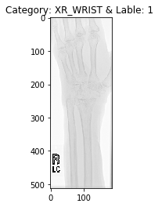

```python
ix = np.random.randint(0, len(valid_mat))
img_path = valid_mat[ix][0]
plt.imshow(io.imread(img_path), cmap='binary')
cat = img_path.split('/')[2]
plt.title('Category: %s & Lable: %d ' %(cat, valid_mat[ix][1]))
plt.show()
```

This can be seen that images vary in resolution and dimension

```python
# look at the pixel values
io.imread(img_path)[0]
```

```
Array([ 99,  99, 102,  82,  73,  71,  66,  69,  68,  64,  62,  63,  62,
        65,  68,  65,  57,  57,  58,  58,  58,  58,  58,  57,  58,  60,
        64,  63,  64,  62,  60,  61,  61,  62,  63,  69,  75,  75,  75,
        74,  71,  74,  75,  74,  73,  76,  76,  77,  77,  71,  75,  76,
        75,  74,  71,  69,  68,  67,  68,  66,  67,  66,  68,  70,  70,
        72,  71,  72,  70,  73,  68,  68,  67,  70,  71,  79,  72,  76,
        71,  79,  79,  78,  79,  78,  79,  80,  79,  79,  76,  78,  80,
        78,  78,  76,  75,  76,  77,  77,  77,  77,  76,  77,  76,  78,
        80,  80,  79,  79,  80,  80,  80,  80,  77,  77,  78,  69,  71,
        76,  73,  73,  73,  73,  74,  74,  72,  70,  68,  70,  74,  78,
        76,  71,  76,  76,  73,  71,  71,  70,  69,  71,  68,  69,  70,
        68,  73,  69,  73,  75,  73,  78,  76,  77,  68,  69,  72,  74,
        80,  77,  81,  84,  84,  84,  86,  89,  87,  91,  95,  93,  93,
        93,  98,  96,  99, 102, 101, 101, 105, 105, 107, 105, 103,  99,
       101, 105, 105], dtype=uint8)
```

### Data Exploration

```python
!ls ../MURA-v1.0/train/
```

[output not shown]

```python
!ls ../MURA-v1.0/train/XR_ELBOW/
```

[output not shown]

So, train dataset has seven study types, each study type has studies on patients stored in folders named like patient001, patient002 etc..

#### Patient count per study type

Let's count number of patients in each study type

```python
data_cat= ['train', 'valid']
study_types = list(os.walk('d:/image datasets/MURA-v1.1/train/'))[0][1] # study types, same for train and valid sets
patients_count = {}  # to store all patients count for each study type, for train and valid sets
for phase in data_cat:
    patients_count[phase] = {}
    for study_type in study_types:
        patients = list(os.walk('d:/image datasets/MURA-v1.1/%s/%s' %(phase, study_type)))[0][1] # patient folder names
        patients_count[phase][study_type] = len(patients)
```

```python
print(study_types)
print()
print(patients_count)
```

```
['XR_ELBOW', 'XR_FINGER', 'XR_FOREARM', 'XR_HAND', 'XR_HUMERUS', 'XR_SHOULDER', 'XR_WRIST']

{'train': {'XR_ELBOW': 1711, 'XR_FINGER': 1865, 'XR_FOREARM': 865, 'XR_HAND': 1945, 'XR_HUMERUS': 587, 'XR_SHOULDER': 2694, 'XR_WRIST': 3267}, 'valid': {'XR_ELBOW': 152, 'XR_FINGER': 166, 'XR_FOREARM': 129, 'XR_HAND': 159, 'XR_HUMERUS': 132, 'XR_SHOULDER': 173, 'XR_WRIST': 207}}
```

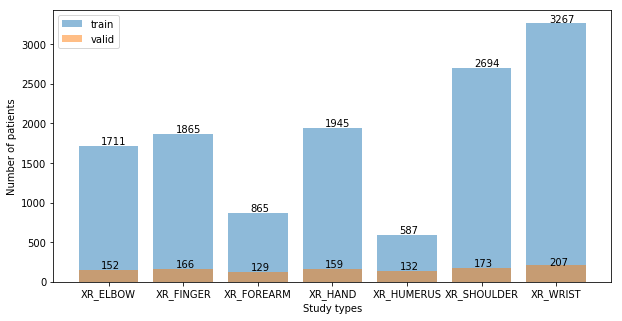

```python
# plot the patient counts per study type

fig, ax = plt.subplots(figsize=(10, 5))
for i, phase in enumerate(data_cat):
    counts = patients_count[phase].values()
    m = max(counts)
    for i, v in enumerate(counts):
        if v==m: ax.text(i-0.1, v+3, str(v))
        else: ax.text(i-0.1, v + 20, str(v))
    x_pos = np.arange(len(study_types))
    plt.bar(x_pos, counts, alpha=0.5)
    plt.xticks(x_pos, study_types)

plt.xlabel('Study types')
plt.ylabel('Number of patients')
plt.legend(['train', 'valid'])
plt.show()
#fig.savefig('images/pcpst.jpg', bbox_inches='tight', pad_inches=0) # name=patient count per study type
```

### Study count

Patients might have multiple studies for a given study type, like a patient may have two studies for wrist, independent of each other.  
Let's have a look at such cases, **NOTE** here study count = number of patients which have same number of studies

```python
# let's find out number of studies per study_type
study_count = {} # to store study counts for each study type
for study_type in study_types:
    BASE_DIR = 'd:/image datasets/MURA-v1.1/train/%s/' % study_type
    study_count[study_type] = defaultdict(lambda:0) # to store study count for current study_type, initialized to 0 by default
    patients = list(os.walk(BASE_DIR))[0][1] # patient folder names
    for patient in patients:
        studies = os.listdir(BASE_DIR+patient)
        study_count[study_type][len(studies)] += 1
```

```python
study_count
```

```
{'XR_ELBOW': defaultdict(<function __main__.<lambda>()>,
             {1: 1669, 3: 1, 2: 41}),
 'XR_FINGER': defaultdict(<function __main__.<lambda>()>,
             {1: 1799, 2: 62, 3: 4}),
 'XR_FOREARM': defaultdict(<function __main__.<lambda>()>, {1: 853, 2: 12}),
 'XR_HAND': defaultdict(<function __main__.<lambda>()>,
             {1: 1875, 2: 67, 3: 3}),
 'XR_HUMERUS': defaultdict(<function __main__.<lambda>()>, {1: 582, 2: 5}),
 'XR_SHOULDER': defaultdict(<function __main__.<lambda>()>,
             {1: 2582, 2: 101, 4: 4, 3: 7}),
 'XR_WRIST': defaultdict(<function __main__.<lambda>()>,
             {1: 3094, 2: 157, 3: 12, 4: 4})}
```

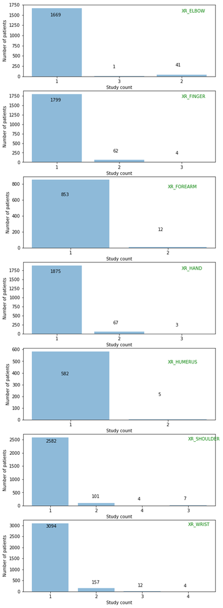

```python
# plot the study count vs number of patients per study type data
fig = plt.figure(figsize=(8, 25))
for i, study_type in enumerate(study_count):
    ax = fig.add_subplot(7, 1, i+1)
    study = study_count[study_type]
    # text in the plot
    m = max(study.values())
    for i, v in enumerate(study.values()):
        if v==m: ax.text(i-0.1, v - 200, str(v))
        else: ax.text(i-0.1, v + 200, str(v))
    ax.text(i, m - 100, study_type, color='green')
    # plot the bar chart
    x_pos = np.arange(len(study))
    plt.bar(x_pos, study.values(), align='center', alpha=0.5)
    plt.xticks(x_pos,  study.keys())
    plt.xlabel('Study count')
    plt.ylabel('Number of patients')
plt.show()
#fig.savefig('images/pcpsc.jpg', bbox_inches='tight', pad_inches=0)
```

### Number of views per study

It can be seen that each study may have more that one view (radiograph image), let' have a look

```python
# let's find out number of studies per study_type
view_count = {} # to store study counts for each study type, study count = number of patients which have similar number of studies
for study_type in study_types:
    BASE_DIR = 'd:/image datasets/MURA-v1.1/train/%s/' % study_type
    view_count[study_type] = defaultdict(lambda:0) # to store study count for current study_type, initialized to 0 by default
    patients = list(os.walk(BASE_DIR))[0][1] # patient folder names
    for patient in patients:
        studies = os.listdir(BASE_DIR + patient)
        for study in studies:
            views = os.listdir(BASE_DIR + patient + '/' + study)
            view_count[study_type][len(views)] += 1
```

```python
view_count
```

```
{'XR_ELBOW': defaultdict(<function __main__.<lambda>()>,
             {3: 638, 2: 724, 4: 275, 5: 65, 1: 35, 6: 10, 7: 7}),
 'XR_FINGER': defaultdict(<function __main__.<lambda>()>,
             {1: 359, 3: 1261, 2: 160, 4: 132, 5: 22, 6: 1}),
 'XR_FOREARM': defaultdict(<function __main__.<lambda>()>,
             {2: 669, 3: 92, 1: 87, 4: 23, 5: 5, 7: 1}),
 'XR_HAND': defaultdict(<function __main__.<lambda>()>,
             {3: 1404, 2: 517, 4: 60, 1: 32, 5: 5}),
 'XR_HUMERUS': defaultdict(<function __main__.<lambda>()>,
             {2: 487, 3: 62, 1: 22, 4: 16, 6: 1, 5: 4}),
 'XR_SHOULDER': defaultdict(<function __main__.<lambda>()>,
             {3: 1004, 4: 904, 1: 320, 2: 515, 5: 72, 6: 5, 11: 1}),
 'XR_WRIST': defaultdict(<function __main__.<lambda>()>,
             {3: 2004, 4: 477, 2: 662, 1: 275, 6: 11, 5: 24, 7: 5, 8: 2})}
```

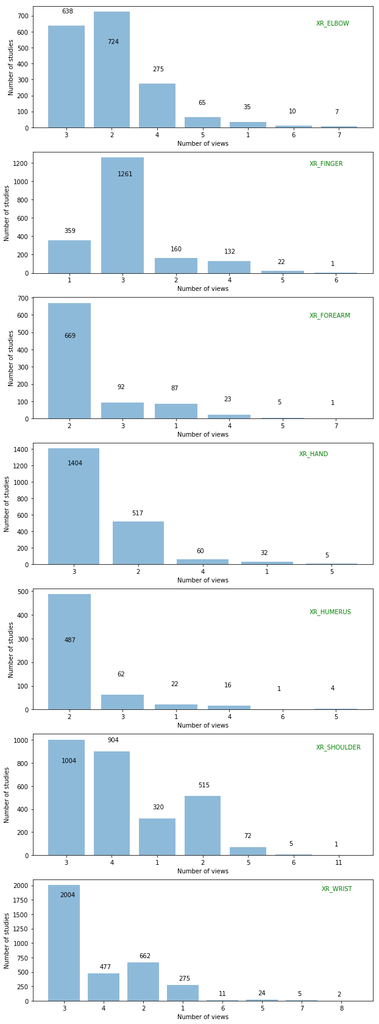

```python
# plot the view count vs number of studies per study type data
fig = plt.figure(figsize=(10, 30))
for i, view_type in enumerate(view_count):
    ax = fig.add_subplot(7, 1, i+1)
    view = view_count[view_type]
    # text in the plot
    m = max(view.values())
    for i, v in enumerate(view.values()):
        if v==m: ax.text(i-0.1, v - 200, str(v))
        else: ax.text(i-0.1, v + 80, str(v))
    ax.text(i - 0.5, m - 80, view_type, color='green')
    # plot the bar chart
    x_pos = np.arange(len(view))
    plt.bar(x_pos, view.values(), align='center', alpha=0.5)
    plt.xticks(x_pos,  view.keys())
    plt.xlabel('Number of views')
    plt.ylabel('Number of studies')
plt.show()
#fig.savefig('images/nsvc.jpg', bbox_inches='tight', pad_inches=0) # name=number of studies view count
```

Most of the studies contain 2, 3 or 4 views